# forceAndCall

# Example of function returning function

We consider the `MASS::mvrnorm` in this section.

`MASS::mvrnorm` draws random numbers from the specified multivariate normal distribution.

- [MASS/mvrnorm.R at master · cran/MASS · GitHub](https://github.com/cran/MASS/blob/master/R/mvrnorm.R)

Let’s imagine the situation that we want to simulate using random numbers drawn from some fixed multivariate normal distribution:

```r
Sigma = ...
for (j in 1 : 1e+6) {
 x = MASS::mvrnorm (Sigma = Sigma);
 ...
}
```

This simulation will waste our time because this code repeats the diagonalization of matrix `Sigma` in the loop. So we want to separate the entire function into two parts, the part of diagonalization of matrix, and the part of generating random numbers.

```r
self = with (new.env (), {
 rnorm_for_loop = \(Sigma, negative = - 1e-3) {
  len = nrow (Sigma);
  if (len != ncol (Sigma)) {
   stop ("Sigma must be a square matrix.");
  }
  eig = eigen (Sigma, symmetric = T);
  val = eig $ value;
  if (any (val < negative)) {
   stop ("Sigma must be positive-definite.");
  }
  val = pmax (sqrt (val), 0);
  mat = eig $ vectors;
  \() mat %*% (val * rnorm (len)) |> drop ();
 };

 as.list (rlang::current_env ());
});
```

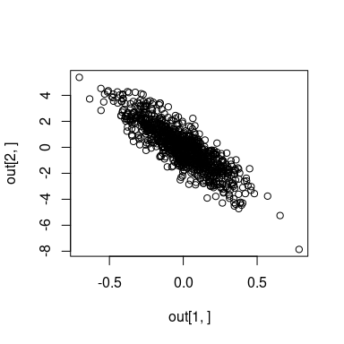

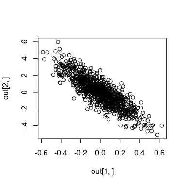

```r
self = with (self, {
 set.seed (NULL);
 Sigma = pracma::randortho (2);
 Sigma = t (Sigma) %*% diag (c (1e-2, 1+2)) %*% Sigma;

 out = purrr::map (1 : 1e+3, \(j) MASS::mvrnorm (1, rep (0, 2), Sigma)) |> do.call (what = cbind);
 plot (out [1, ], out [2, ]);

 go = forceAndCall (1, rnorm_for_loop, Sigma);
 out = purrr::map (1 : 1e+3, \(j) go ()) |> do.call (what = cbind);
 plot (out [1, ], out [2, ]);

 as.list (rlang::current_env ());
});
```

The advantage of separation is measured as follows:

```r
self = with (self, {
 set.seed (NULL);
 n = 1e+2;
 Sigma = pracma::randortho (n);
 Sigma = t (Sigma) %*% diag (runif (n)) %*% Sigma;
 N = 1e+2;
 do_nothig = \(a) a;
 microbenchmark::microbenchmark (
  MASS = {
   a = 0;
   out = MASS::mvrnorm (N, rep (0, n), Sigma);
   for (j in 1 : N) {
    a = a + out [(1 : n) + n * (j - 1)];
   }
   do_nothig (a);
  }
  , Moop = {
   a = 0;
   for (j in 1 : N) {
    a = a + MASS::mvrnorm (1, rep (0, n), Sigma);
   }
   do_nothig (a);
  }
  , loop = {
   a = 0;
   go = forceAndCall (1, rnorm_for_loop, Sigma);
   for (j in 1 : N) {
    a = a + go ();
   }
   do_nothig (a);
  }
 ) |> print ();

 as.list (rlang::current_env ());
});
```

```
Unit: milliseconds
 expr        min         lq       mean     median         uq        max neval
 MASS   3.709957   3.835241   4.127656   3.921489   4.148548   6.503495   100
 Moop 263.563128 266.254576 270.030657 268.622712 270.463328 384.314231   100
 loop   3.542904   3.675890   3.960894   3.759987   4.152774   6.377058   100
```

We know that we don’t need `forceAndCall` to call `rnorm_for_loop`, but automatism helps us preventing from bugs.

[^1]: [Johan Cruyff - Wikipedia](https://en.wikipedia.org/wiki/Johan_Cruyff)